# 1. Overview

## 1. Overview

This report describes the process followed to build a predictive model to estimate the nature of exercise performed by subjects as part of the Weight Lifting data set created as documented here: http://groupware.les.inf.puc-rio.br/har.

### 1.1 Purpose

My objective was to predict one of five values (A-E) which indicated how well or poorly subjects performed exercises. This target variable was labelled as the classe variable within the dataset.

### 1.2 Libraries

```r
library(dplyr)
library(tidyr)
library(caret)
library(corrplot)
library(randomForest)
```

## 2. Data Processing

Read in the data, ignoring NA values and their equivalents then remove those variables which add no value to our prediction, such as user_name and new_window.

```r
testing_data <- read.table("pml-testing.csv", header = TRUE, sep = ",",na.strings = c("NA", ""))
training_data <- read.table("pml-training.csv", header = TRUE, sep = ",", na.strings = c("NA", ""), stringsAsFactors=FALSE)

ignoredvariableregex  <- "X|user_name|_timestamp|new_window|num_window"
includedvariabledf  <- select(training_data,-matches(ignoredvariableregex))
includedvariabledf_testing  <- select(testing_data,-matches(ignoredvariableregex))
```

We tidy up the training data set first, using the tidied dataset of 127 variables, identify and remove those for which values are missing. This creates a reduced variable dataset containing 41 columns. We then set the classe variable to be a factor. Finally, we identify which of the remaining variables have a zero, or near-zero variance - none.

```r
navarsidentified  <- is.na(includedvariabledf)
numnavars  <- colSums(navarsidentified)
completevars  <- numnavars == 0

reducedvardf  <- includedvariabledf[completevars]

reducedvardf$classe  <- as.factor(reducedvardf$classe)

nearzerovars  <- nearZeroVar(reducedvardf[sapply(reducedvardf, is.numeric)], saveMetrics=TRUE)
filter(nearzerovars, zeroVar==TRUE | nzv == TRUE)
```

```
## [1] freqRatio     percentUnique zeroVar       nzv
## <0 rows> (or 0-length row.names)
```

```r
refinedtrainingset  <- reducedvardf
```

Now we follow the same procedure for the testing data set.

```r
navarsidentified  <- is.na(includedvariabledf_testing)
numnavars  <- colSums(navarsidentified)
completevars  <- numnavars == 0

# We now have a reduced variable dataset containing 41 columns.
reducedvardf  <- includedvariabledf_testing[completevars]

refinedtestingset <- includedvariabledf_testing[colSums(is.na(includedvariabledf_testing)) == 0]
```

## 3. Data Splitting

We have an ample number of observations to allow us to create our own training, testing and validation datasets from the offical pml_training set provided. We will use the ratio of 60% training, 20% testing and 20% validation.

```r
inTrain  <- createDataPartition(y=refinedtrainingset$classe, p=0.6, list=FALSE)
mytraining  <- refinedtrainingset[inTrain,]
mytestingandvalidation  <- refinedtrainingset[-inTrain,]

# This takes 50% of 40% - 20% each for validation and testing sets.
inTesting  <- createDataPartition(y=mytestingandvalidation$classe, p=0.5, list=FALSE)
mytesting  <- mytestingandvalidation[inTesting,]
myvalidation  <- mytestingandvalidation[-inTesting,]
```

## 4. Principal Component Analysis

We identify correlations between numeric variables which suggests performing a PCA exercise would be beneficial. Performing PCA allowed the number of predictor variables to be reduced from 41 to 23 which would still capture 95% of the variance. We then apply the PCA model to the training, testing and validation data sets.

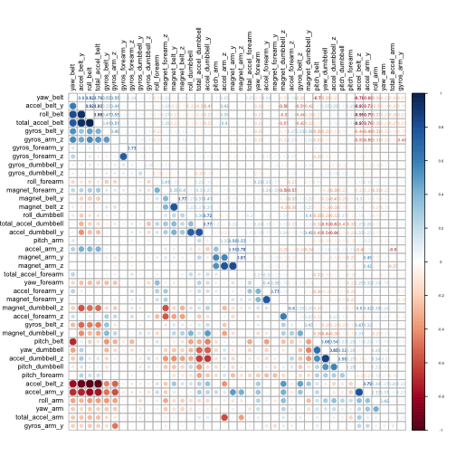

```r
predictor_corr <- round(cor(mytraining[sapply(mytraining, is.numeric)]), 2)

par(ps=5)
corrplot.mixed(predictor_corr, order = "hclust", tl.col="black", diag = "n", tl.pos = "lt",
               lower = "circle", upper = "number", tl.cex = 1.5, mar=c(1,0,1,0))
```

```r
preproc  <- preProcess(mytraining[,-41],method="pca")

mytrainingpc  <- predict(preproc,mytraining[,-41])
mytestinggpc  <- predict(preproc,mytesting[,-41])
myvalidationpc  <- predict(preproc,myvalidation[,-41])
```

## 5. Model Fitting with PCA

As we are performing a multi-value classification, a random forest method is suitable to attempt. We train the using cross-validation and predict the values against the validation data set. We create a confusion matrix which will identify the accuracy of almost 97%.

We can calculate the out of sample error by subtracting the accuracy rate from 1.The out-of-sample error is around 3%.

```r
model.1.rf  <- train(mytraining$classe ~ ., method="rf", data=mytrainingpc,trControl = trainControl(method = "cv", number = 4),ntree=100,importance=TRUE)

model.1.rf.validate <- predict(model.1.rf, myvalidationpc)

confusionmatrix <- confusionMatrix(myvalidation$classe, model.1.rf.validate)
confusionmatrix$table
```

```
##           Reference
## Prediction    A    B    C    D    E
##          A 1107    1    3    3    2
##          B   15  734    8    1    1
##          C    2   13  660    7    2
##          D    0    0   26  615    2
##          E    1   10   10    1  699
```

```r
outofsampleerror  <- 1 - (postResample(myvalidation$classe, model.1.rf.validate)[[1]])
```

## 5. Model Fitting without PCA

We can now try and create the same model without PCA. We create a confusion matrix which will identify the accuracy of over 99%. We can calculate the out of sample error by subtracting the accuracy rate from 1.The out-of-sample error is less than 1%.

```r
model.2.rf <- train(classe ~ ., method="rf", data=mytraining,trControl = trainControl(method = "cv", number = 4),ntree=100,importance=TRUE)

# Predict the values using the validation dataset.
model.2.rf.validate <- predict(model.2.rf, myvalidation)


confusionmatrix <- confusionMatrix(myvalidation$classe, model.2.rf.validate)
confusionmatrix$table
```

```
##           Reference
## Prediction    A    B    C    D    E
##          A 1112    0    2    0    2
##          B   10  745    2    0    2
##          C    0    5  674    5    0
##          D    0    0    7  635    1
##          E    0    0    0    2  719
```

```r
outofsampleerror  <- 1 - (postResample(myvalidation$classe, model.2.rf.validate)[[1]])
```

## 6. Final Model without PCA

Based on the accuracy values returned, performing PCA on our dataset causes a loss in accuracy of around 2%.  
On this basis,I have decided to use the non-PCA model to proceed to testing phase.

```r
model.2.rf.test  <- predict(model.2.rf, mytesting)

confusionmatrix <- confusionMatrix(mytesting$classe, model.2.rf.test)
confusionmatrix$table
```

```
##           Reference
## Prediction    A    B    C    D    E
##          A 1114    1    1    0    0
##          B   12  740    5    1    1
##          C    0    0  682    2    0
##          D    0    1    8  633    1
##          E    0    0    2    3  716
```

```r
outofsampleerror  <- 1 - (postResample(mytesting$classe, model.2.rf.test)[[1]])
```

## 7. Final Test

```r
model.2.answers   <- predict(model.2.rf, refinedtestingset[,-41])
model.2.answers
```

```
##  [1] B A B A A E D B A A B C B A E E A B B B
## Levels: A B C D E
```